# Joint analysis of longitudinal and recurrent event data: A functional regression approach with autoregressive frailty

Zifang Kong

2025-03-05

In this vignette, we aim to demonstrate how to use our package to jointly analyze longitudinal and recurrent event data using functional regression approach with autoregressive frailty.

```r
library(devtools)
load_all()
library(FunSurv)
packageVersion("FunSurv")
```

```
#> [1] '0.1.0'
```

### Model Formulation

Let $T_{ij}$ denote the time of the $j$th event for subject $i$, and let $C_i$ represent the censoring time. The observed event time, accounting for right censoring, is $\tilde{T}_{ij}=\min(T_{ij}, C_i)$, and $\delta_{ij}=I(T_{ij}\leq C_i)$ serves as an indicator of whether the $j$th event for subject $i$ is observed. Building on the survival analysis framework with time-dependent, correlated frailty introduced by Yau and McGilchrist (1998), the hazard function is specified as
$$\begin{equation}\label{hazardFunction}
\begin{aligned}
h(t; \boldsymbol{Z}_i, {X}_i(\cdot))=h_{0}(t-t_{i,j-1}) \exp
\left(\eta_{ij}\right),
\end{aligned}
\end{equation}$$
where $h_0(\cdot)$ is the baseline hazard function, and $\eta_{ij} = \boldsymbol{\alpha}^{\top}\boldsymbol{Z}_i +\int_{t_{i, j-1}}^{t}{X}_{i}(s)\beta(s)ds + v_{ij}$. Here, $t_{i, j-1}$ is the previous event time with $t_{i0} = 0$. $\boldsymbol{\alpha}$ is the fixed effect parameter associated with the time-invariant covariates $\boldsymbol{Z}_i$, and $\beta(t)$ is a time-varying coefficient that captures the effect of functional predictor ${X}_{i}(t)$ on the hazard rate of recurrent events.

### Import data

Suppose we have collected data on both longitudinal measurements and recurrent event outcomes. The **sdat** dataset contains information on recurrent event outcomes, including the event start time (*t_start*), event end time (*t_stop*), censoring time (*censoring_time*), event status (*status*), and a scalar covariate (*z1*).

```r
data("simDat")
head(sdat)
```

```
#>    id event  t_start   t_stop censoring_time status z1
#> 1   1     1 0.000000 0.231175       2.031394      1  0
#> 2   1     2 0.231175 1.014917       2.031394      1  0
#> 3   1     3 1.014917 2.031394       2.031394      0  0
#> 4   2     1 0.000000 0.398999       0.398999      0  1
#> 13  3     1 0.000000 1.418417       2.281943      1  1
#> 11  3     2 1.418417 2.281943       2.281943      0  1
```

The **fdat** contains longitudinal measurements (*x*), recorded at multiple time points (*time*), for each subject (*id*)

```r
head(fdat)
```

```
#>   id time         x
#> 1  1  0.2 -1.638517
#> 2  1  0.4 -1.677114
#> 3  1  0.6 -1.280659
#> 4  1  0.9 -1.225097
#> 5  1  1.0 -1.534405
#> 6  1  1.2 -1.697173
```

We use the *plotEvents* function in **reReg** package (Chiou et al. (2023)) to create a recurrent event plot. The horizontal axis represents the subjects’ follow-up time, while the vertical axis represents individuals, sorted by the follow-up duration. Each green dot indicates a recurrent event.

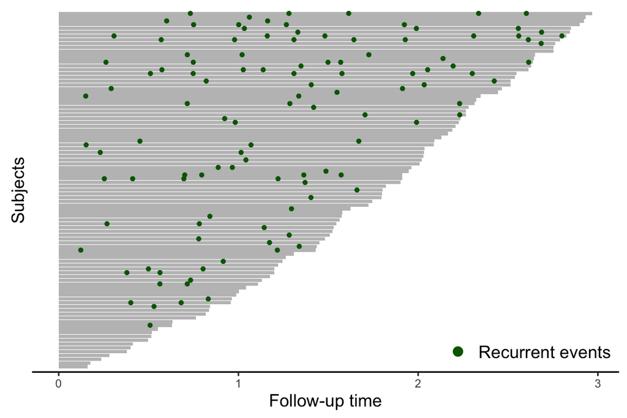

```r
reReg::plotEvents(with(sdat, Recur(t_stop, id, status)), xlab="Follow-up time", ylab="Subjects", cex=1,recurrent.color="darkgreen", control=list(alpha = 0.8, base_size=8))
```

### Fit the AR1_FRIALTY model

The *AR1_FRIALTY* model employs a two-step procedure to fit the joint model. First, we apply the functional principal component analysis (FPCA) for the longitudinal outcome and obtain the event-specific FPC scores. The calculation of event-specific FPC scores involves 1) calculate the overall FPC scores using *PACE* function in the **MFPCA** package (Happ and Greven (2018)); 2) incorporate the overall FPC scores to obtain the event-specific FPC scores. The results of the first step is a data frame of 3 columns of FPC scores, where each column is associated with a leading functional principal component.

In the second step, the obtained scores are incorporated into a dynamic recurrent frailty model with an autoregressive structure to account for within-subject correlations across recurrent events.

```r
args(AR1_FRAILTY)
```

```
#> function (formula, sdat, fdat, para0 = c(0.5, 0.5), nbasis = 10,
#>     pve = 0.9, npc = NULL, makePD = FALSE, cov.weight.type = "none",
#>     iter.max = 50, eps = 1e-06)
#> NULL
```

- `formula` A formula, with the response on the left of a ~ operator being a *Recur* object as returned by function Recur in **reda**, and scalar covariates on the right.
- `sdat` is a data frame containing information of recurrent event outcomes.
- `fdat` is data frame containing longitudinal measurements.
- `para0` A vector of initial values for $\theta^2$ and auto-regressive coefficient $\rho$. Both defaults to 0.5.
- `nbasis` is an integer specifying the number of B-spline basis functions used for estimating the mean function and performing bivariate smoothing of the covariance surface (see *fpca.sc* in the **refund** package Crainiceanu et al. (2013)).
- `pve` is numerical value between 0 and 1, representing the proportion of variance explained used to choose the number of functional principal components. Defaults to 0.9.
- `npc` is an integer specifying the number of functional principal components.
- `makePD`is boolean value for should positive definiteness be enforced for the covariance surface estimate? (cf. *fpca.sc* in **refund** Crainiceanu et al. (2013)).
- `cov.weight.type` defines the type of weighting used for the smooth covariance estimate. Defaults to “none”, i.e. no weighting. Alternatively, “counts” (corresponds to *fpca.sc* in **refund** Crainiceanu et al. (2013)) weights the pointwise estimates of the covariance function by the number of observation points.
- `iter.max` Maximum number of iterations for both inner iteration and outer iteration.
- `eps` Tolerance criteria for a possible infinite coefficient value.

We set the percentage of variance explained to 90% to determine a finite number of FPC components, resulting in three FPC components

```r
fit <- AR1_FRAILTY(formula=Recur(t_start %to% t_stop, id, status) ~ z1, sdat=sdat, fdat=fdat, nbasis=10, pve=0.9)
summary(fit)
```

```
#> Call:
#> AR1_FRAILTY(formula = Recur(t_start %to% t_stop, id, status) ~
#>     z1, sdat = sdat, fdat = fdat, nbasis = 10, pve = 0.9)
#>
#>  Coefficients:
#>        Estimate     SE   p-value
#> z1     -2.78199 0.4095 1.098e-11 ***
#> score1 -0.16928 0.2201    0.4419
#> score2 -0.16854 0.2767    0.5425
#> score3  0.26826 0.4385    0.5407
#>
#>  Variance component and auto-regressive coefficient:
#>        Estimate     SE  p-value
#> theta2  0.36410 0.2588 0.159441
#> rho     0.70569 0.2190 0.001269 **
#> ---
#> Signif. codes:  0 '***' 0.001 '**' 0.01 '*' 0.05 '.' 0.1 ' ' 1
```

The functional coefficient $\beta(t)$ can be plotted via `plot()`:

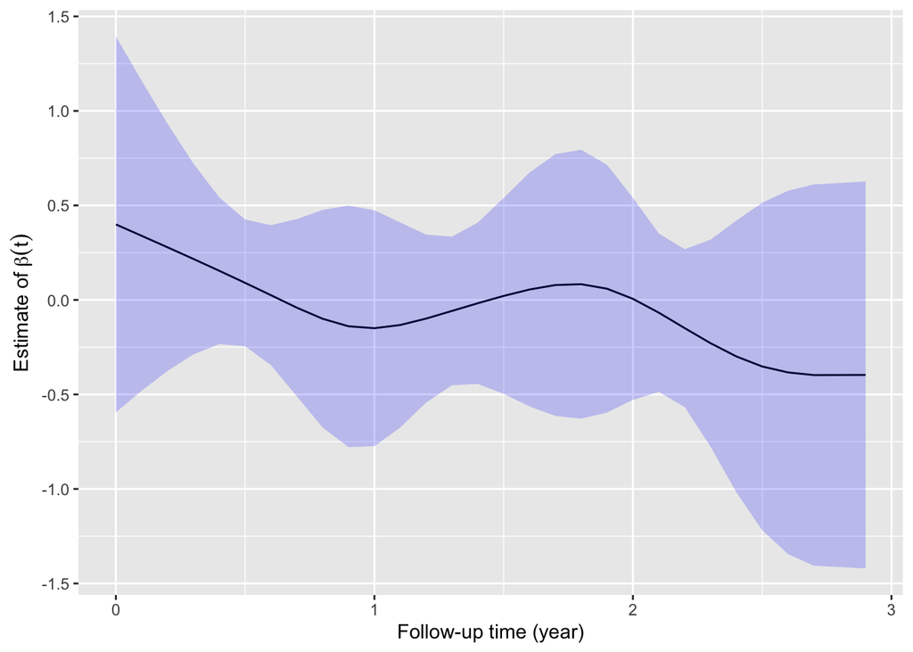

```r
plot(fit, which="beta")
```

The plot below shows the estimated baseline survival probability.

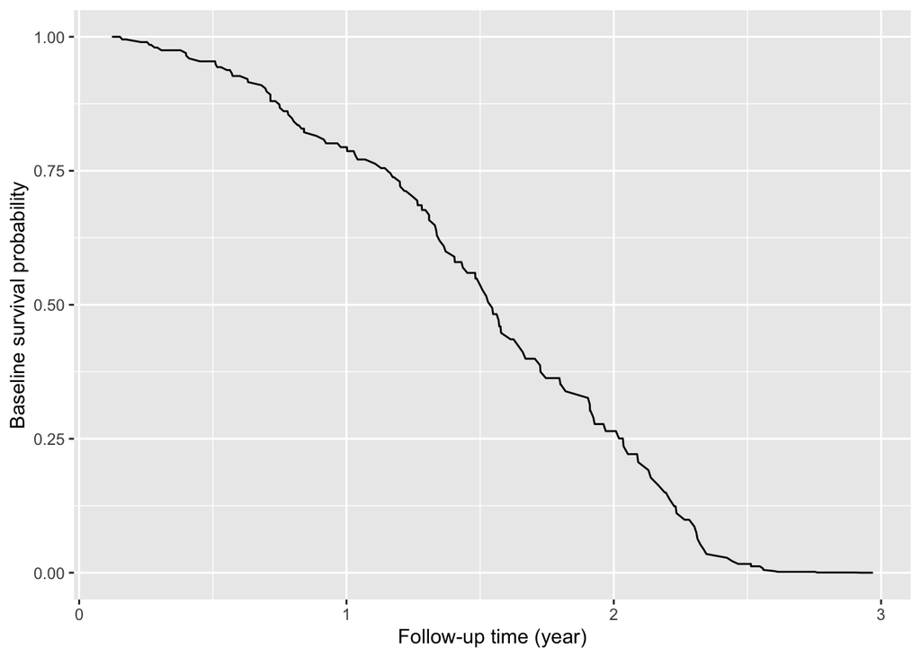

```r
plot(fit, which="basesurv")
```

The plot below demonstrates the three functional principal components estimated from longitudinal measurements.

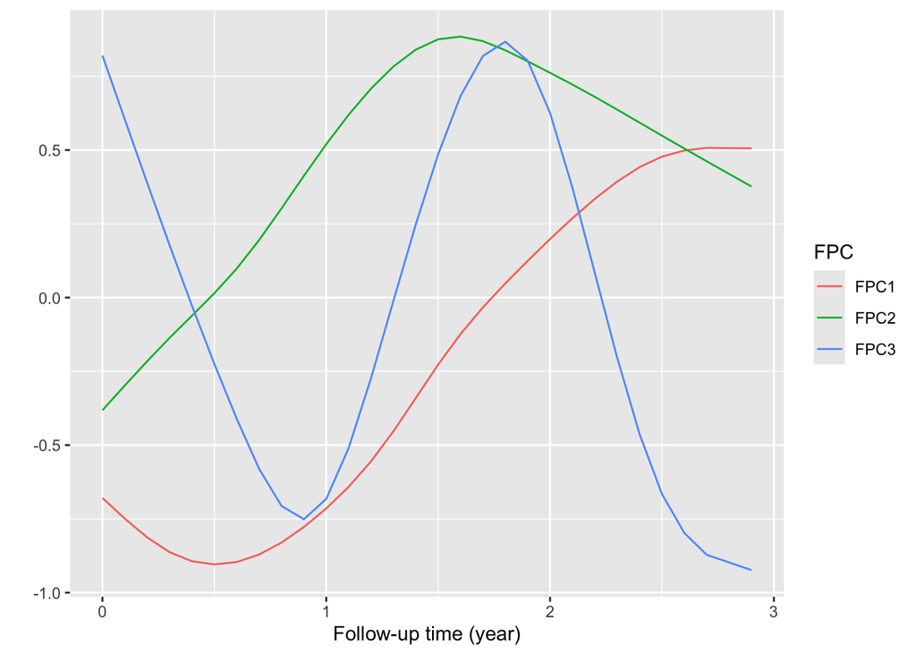

```r
plot(fit, which="fpc")
```

### References

Chiou, Sy Han, Gongjun Xu, Jun Yan, and Chiung-Yu Huang. 2023. “Regression Modeling for Recurrent Events Possibly with an Informative Terminal Event Using r Package reReg.” *Journal of Statistical Software* 105: 1–34.

Crainiceanu, Ciprian, Philip Reiss, Jeff Goldsmith, Maintainer Lei Huang, Lan Huo, Fabian Scheipl, and Bruce Swihart. 2013. “Package ‘Refund’.” Citeseer.

Happ, Clara, and Sonja Greven. 2018. “Multivariate Functional Principal Component Analysis for Data Observed on Different (Dimensional) Domains.” *Journal of the American Statistical Association* 113: 649–59. https://doi.org/10.1080/01621459.2016.1273115.

Yau, KKW, and CA McGilchrist. 1998. “ML and REML Estimation in Survival Analysis with Time Dependent Correlated Frailty.” *Statistics in Medicine* 17 (11): 1201–13.